# 成為初級資料分析師 | Python 機器學習

> 迴歸

## 郭耀仁

## 大綱

- 線性迴歸模型
- 正規方程

## 線性迴歸模型

## 線性迴歸模型的 E, T, 與 P

> A computer program is said to learn from experience E with respect to some class of tasks T and performance measure P if its performance at tasks in T, as measured by P, improves with experience E.

> Tom Mitchel

## E: Experience

NBA 球員的身高與體重資料

```python
import pandas as pd

csv_url = "https://pyml.s3-ap-northeast-1.amazonaws.com/nba/players.csv"
players = pd.read_csv(csv_url)
print(players.shape)
players.head()
```

```
(497, 18)
```

|  | firstName | lastName | temporaryDisplayName | personId | teamId | jersey | pos | heightFeet | heightInches | heightMeters | weightPounds | weightKilograms | dateOfBirthUTC | nbaDebutYear | yearsPro | collegeName | lastAffiliation | country |
| --- | --- | --- | --- | --- | --- | --- | --- | --- | --- | --- | --- | --- | --- | --- | --- | --- | --- | --- |
| 0 | Steven | Adams | Adams, Steven | 203500 | 1610612760 | 12.0 | C | 6 | 11 | 2.11 | 265 | 120.2 | 1993-07-20 | 2013.0 | 6 | Pittsburgh | Pittsburgh/New Zealand | New Zealand |
| 1 | Bam | Adebayo | Adebayo, Bam | 1628389 | 1610612748 | 13.0 | C-F | 6 | 9 | 2.06 | 255 | 115.7 | 1997-07-18 | 2017.0 | 2 | Kentucky | Kentucky/USA | USA |
| 2 | LaMarcus | Aldridge | Aldridge, LaMarcus | 200746 | 1610612759 | 12.0 | C-F | 6 | 11 | 2.11 | 250 | 113.4 | 1985-07-19 | 2006.0 | 13 | Texas | Texas/USA | USA |
| 3 | Kyle | Alexander | Alexander, Kyle | 1629734 | 1610612748 | 17.0 | F-C | 6 | 10 | 2.08 | 216 | 98.0 | 1996-10-21 | NaN | 0 | Tennessee | Tennessee/Canada | Canada |
| 4 | Nickeil | Alexander-Walker | Alexander-Walker, Nickeil | 1629638 | 1610612740 | 0.0 | G | 6 | 5 | 1.96 | 205 | 93.0 | 1998-09-02 | 2019.0 | 0 | Virginia Tech | Virginia Tech/Canada | Canada |

```python
from sklearn.model_selection import train_test_split

X = players["heightMeters"].values.reshape(-1, 1)
y = players["weightKilograms"].values
X_train, X_validation, y_train, y_validation = train_test_split(X, y, test_size=0.33, random_state=42)
```

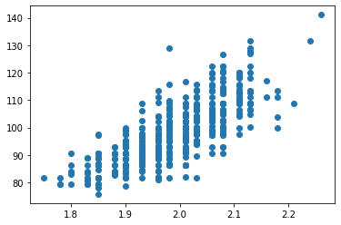

```python
import matplotlib.pyplot as plt

fig, ax = plt.subplots()
ax.scatter(X, y)
plt.show()
```

## T: Task

利用 NBA 球員的身高預測他的體重

## P: Performance

- 跟 $f$ 長得很像的 $h$，預測體重與真實體重接近
- 跟 $f$ 長得不太像的 $h$，預測體重與真實體重相差較遠

## 線性迴歸模型 in short

建立一個輸入向量 $x$ 能夠得到純量 $\hat{y}$ 輸入的系統 $h$，$x$ 與 $\hat{y}$ 符合線性關係，其中向量 $w$ 稱為是系統的參數

$$\hat{y} = h(x) = w_0 + w_1 x_1 + w_2 x_2 + ... + w_n x_n \\ \hat{y} = h(x) = w_0 x_0 + w_1 x_1 + w_2 x_2 + ... + w_n x_n \text{ , where } x_0 = 1 \\ \hat{y} = h(x) = w^Tx$$

## 將 $h$ 表示得更廣泛

$$\hat{y} = h(X) = \begin{bmatrix} x_{00}, x_{01}, ..., x_{0n} \\ x_{10}, x_{11}, ..., x_{1n} \\.\\.\\.\\ x_{m0}, x_{m1}, ..., x_{mn} \end{bmatrix} \begin{bmatrix} w_0 \\ w_1 \\.\\.\\.\\ w_n \end{bmatrix} = Xw$$

## $w$：系統的參數

- $w_i$ 為正，表示 $x_i$ 這個特徵對 $\hat{y}$ 的影響為正向
- $w_i$ 為負，表示 $x_i$ 這個特徵對 $\hat{y}$ 的影響為負向
- $w_i$ 為零，表示 $x_i$ 這個特徵對 $\hat{y}$ 沒有影響

## 使用 MSE（Mean Squared Error）評估 $h$ 跟 $f$ 的相似程度

$$MSE_{test} = \frac{1}{m}\sum_i(\hat{y}^{(test)} - y^{(test)})_i^2$$

## 將所有球員身高輸入 $h$，獲得預測體重 $\hat{y}^{(test)}$，跟實際體重 $y^{(test)}$ 比較

## 當預測體重 $\hat{y}^{(test)}$，跟體重 $y^{(test)}$ 相同，$MSE_{test}$ 為零

## 使用 Scikit-Learn API 尋找 $w$

```python
from sklearn.linear_model import LinearRegression

lr = LinearRegression()
lr.fit(X_train, y_train)
print(lr.intercept_) # w_0
print(lr.coef_)      # w_1
```

```
-104.53978433115957
[102.04130295]
```

## 使用 $w$ 作預測

```python
y_hat = lr.predict(X_validation)
print(y_hat)
```

```
[102.60406065 100.56323459  89.33869127 102.60406065 100.56323459
 107.7061258   84.23662612  95.46116945  95.46116945 105.66529974
 100.56323459 100.56323459 105.66529974 102.60406065  84.23662612
  92.39993036 110.76736489  92.39993036  92.39993036  97.50199551
  92.39993036 112.80819095  82.19580006  92.39993036  97.50199551
 102.60406065  89.33869127  84.23662612 102.60406065  84.23662612
  92.39993036  95.46116945 105.66529974 110.76736489  89.33869127
  97.50199551  97.50199551  95.46116945  89.33869127  95.46116945
 105.66529974  95.46116945  92.39993036 100.56323459 110.76736489
 107.7061258   89.33869127 102.60406065  95.46116945  89.33869127
  95.46116945  92.39993036  92.39993036 102.60406065 110.76736489
 100.56323459 110.76736489 102.60406065  89.33869127 100.56323459
  87.29786521 105.66529974  95.46116945  89.33869127  87.29786521
 107.7061258   89.33869127  97.50199551 100.56323459  89.33869127
 107.7061258   79.13456098  79.13456098 107.7061258   95.46116945
  92.39993036  82.19580006 107.7061258  105.66529974  89.33869127
  84.23662612  87.29786521 107.7061258  112.80819095  84.23662612
  95.46116945  84.23662612  87.29786521  97.50199551 100.56323459
  95.46116945 112.80819095 102.60406065 107.7061258   89.33869127
 110.76736489 107.7061258   97.50199551  89.33869127 102.60406065
  97.50199551  97.50199551 105.66529974  97.50199551 112.80819095
  95.46116945 107.7061258  112.80819095  97.50199551 102.60406065
 105.66529974 105.66529974 107.7061258  107.7061258   87.29786521
 100.56323459  97.50199551 100.56323459  87.29786521  87.29786521
  97.50199551 107.7061258   89.33869127 112.80819095  89.33869127
 117.9102561  102.60406065  92.39993036  92.39993036 112.80819095
  84.23662612  97.50199551 107.7061258  102.60406065  79.13456098
  97.50199551  97.50199551  97.50199551  95.46116945  92.39993036
  89.33869127  77.09373492  77.09373492 105.66529974  95.46116945
 110.76736489  92.39993036  97.50199551 102.60406065 102.60406065
  89.33869127  92.39993036 107.7061258  112.80819095  92.39993036
  95.46116945  92.39993036  84.23662612 105.66529974 107.7061258
  95.46116945 100.56323459  95.46116945  84.23662612  97.50199551]
```

## 以 MSE 評估 $h$ 與 $f$ 的相似程度

```python
from sklearn.metrics import mean_squared_error

mse = mean_squared_error(y_validation, y_hat)
print(mse)
```

```
50.87038768745247
```

## 正規方程 Normal Equation

## `lr.fit(X_train, y_train)` 發生了什麼神奇的事情？

## 要看一下公式

$$ \bigtriangledown_w MSE_{train} = 0 \\ \bigtriangledown_w \frac{1}{m}\sum_i(\hat{y}^{(train)} - y^{(train)})_i^2 = 0\\ $$

## 看公式之前複習幾個向量、矩陣相乘的特性

- $x$ 與 $y$ 兩個維度相同的向量相乘為 $x^Ty$、亦等於 $y^Tx$
- $A$ 與 $B$ 矩陣相乘後的轉置運算為 $(AB)^T = B^TA^T$
- $Ax = b$ 的解為 $x = A^{-1}b$

## $x$ 與 $y$ 兩個維度相同的向量相乘為 $x^Ty$、亦等於 $y^Tx$

```python
import numpy as np

x = np.array([1, 2, 3]).reshape(-1, 1)
y = np.array([4, 5, 6]).reshape(-1, 1)
print(x.T.dot(y))
print(y.T.dot(x))
```

[output not shown]

## $A$ 與 $B$ 矩陣相乘後的轉置運算為 $(AB)^T = B^TA^T$

```python
A = np.arange(1, 7).reshape(2, 3)
B = np.arange(1, 7).reshape(3, 2)
print((A.dot(B)).T)
print(B.T.dot(A.T))
```

```
[[22 49]
 [28 64]]
[[22 49]
 [28 64]]
```

## $Ax = b$ 的解為 $x = A^{-1}b$

$$ \begin{cases} x_1 + 2x_2 = 5 \\ 3x_1 + 4x_2 = 6 \end{cases} \\ \begin{bmatrix} 1 & 2 \\ 3 & 4 \end{bmatrix} \begin{bmatrix} x_1 \\ x_2 \end{bmatrix} = \begin{bmatrix} 5 \\ 6 \end{bmatrix} \\ $$

```python
A = np.array([1, 2, 3, 4]).reshape(2, 2)
b = np.array([5, 6]).reshape(2, 1)
A_inv = np.linalg.inv(A)
x = A_inv.dot(b)
print(A.dot(x))
print(x)
```

```
[[5.]
 [6.]]
[[-4. ]
 [ 4.5]]
```

## 機器學習的任務：找出一組向量 $w$ 讓訓練資料的 $MSE_{train}$ 最小

$$\bigtriangledown_w MSE_{train} = 0 \\ \bigtriangledown_w \frac{1}{m}\sum_i(\hat{y}^{(train)} - y^{(train)})_i^2 = 0\\ \frac{1}{m} \bigtriangledown_w (\hat{y}^{(train)} - y^{(train)})^T(\hat{y}^{(train)} - y^{(train)}) = 0\\ \bigtriangledown_w (X^{(train)}w - y^{(train)})^T(X^{(train)}w - y^{(train)}) = 0 \\ \frac{\partial}{\partial w} (w^TX^{(train)T}X^{(train)}w - 2w^TX^{(train)T}y^{(train)} + y^{(train)T}y^{(train)}) = 0 \\ 2X^{(train)T}X^{(train)}w - 2X^{(train)T}y^{(train)} = 0 \\ w = (X^{(train)T}X^{(train)})^{-1}X^{(train)T}y^{(train)} $$

## 這個求解稱為 normal equations，又稱 closed form solution

$$w = (X^{(train)T}X^{(train)})^{-1}X^{(train)T}y^{(train)}$$

## 給定 $X_{train}$ 與 $y_{train}$ 利用 normal equations 求 $w$

```python
X = players["heightMeters"].values.reshape(-1, 1)
y = players["weightKilograms"].values
X_0 = np.ones(X.shape[0]).reshape(-1, 1)
X = np.concatenate([X_0, X], axis=1)
X_train, X_validation, y_train, y_validation = train_test_split(X, y, test_size=0.33, random_state=42)
```

```python
def get_w_ne(X_train, y_train):
    X_train_T = np.transpose(X_train)
    X_train_T_X_train = X_train_T.dot(X_train)
    X_train_T_X_train_inverse = np.linalg.inv(X_train_T_X_train)
    w = X_train_T_X_train_inverse.dot(X_train_T.dot(y_train))
    return w
```

```python
w = get_w_ne(X_train, y_train)
print(w)
```

```
[-104.53978433  102.04130295]
```

## 給定 $w$、$X_{validation}$ 計算 $MSE_{validation}$

```python
y_hat = X_validation.dot(w)
n_validation_data = X_validation.shape[0]
mse_validation = ((y_hat - y_validation)**2).sum() / n_validation_data
print(mse_validation)
```

```
50.870387687440974
```

## 將 $h$ 在訓練資料上描繪出來

```python
def get_h_plot(w):
    X_pred = np.linspace(X_train[:, 1].min(), X_train[:, 1].max(), 100)
    X_0 = np.ones(X_pred.size).reshape(-1, 1)
    X_pred_X_0 = np.concatenate([X_0, X_pred.reshape(-1, 1)], axis=1)
    y_pred = X_pred_X_0.dot(w)
    fig, ax = plt.subplots()
    ax.scatter(X_train[:, 1], y_train, label="train", s=5)
    ax.plot(X_pred, y_pred, label="h", c="red", linewidth=2)
    ax.legend()
    plt.show()
```

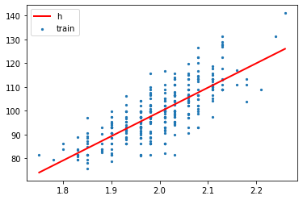

```python
get_h_plot(w)
```

## 隨堂練習：用球員身高預測場均助攻數 `apg`

```python
csv_url = "https://pyml.s3-ap-northeast-1.amazonaws.com/nba/careerSummaries.csv"
career_summaries = pd.read_csv(csv_url)
career_summaries.head()
```

|  | personId | tpp | ftp | fgp | ppg | rpg | apg | bpg | mpg | spg | ... | ftm | fta | pFouls | points | gamesPlayed | gamesStarted | plusMinus | min | dd2 | td3 |
| --- | --- | --- | --- | --- | --- | --- | --- | --- | --- | --- | --- | --- | --- | --- | --- | --- | --- | --- | --- | --- | --- |
| 0 | 203500 | 10.0 | 55.8 | 58.9 | 9.8 | 7.6 | 1.2 | 1.0 | 26.8 | 0.9 | ... | 867.0 | 1555.0 | 1373.0 | 5140.0 | 525.0 | 461.0 | 1614.0 | 14092.0 | 111.0 | 0.0 |
| 1 | 1628389 | 11.4 | 71.1 | 55.8 | 10.5 | 7.7 | 2.9 | 0.9 | 25.5 | 0.8 | ... | 531.0 | 747.0 | 505.0 | 2259.0 | 216.0 | 112.0 | 197.0 | 5515.0 | 57.0 | 3.0 |
| 2 | 200746 | 31.2 | 81.1 | 49.1 | 19.5 | 8.3 | 2.0 | 1.1 | 34.4 | 0.7 | ... | 3579.0 | 4414.0 | 2473.0 | 19599.0 | 1003.0 | 962.0 | 2799.0 | 34517.0 | 351.0 | 0.0 |
| 3 | 1629734 | 0.0 | 0.0 | 0.0 | 0.0 | 0.0 | 0.0 | 0.0 | 0.0 | 0.0 | ... | NaN | NaN | NaN | NaN | NaN | NaN | NaN | NaN | NaN | NaN |
| 4 | 1629638 | 34.2 | 60.7 | 33.9 | 5.1 | 2.0 | 1.8 | 0.2 | 12.2 | 0.3 | ... | 17.0 | 28.0 | 46.0 | 211.0 | 41.0 | 0.0 | -62.0 | 500.0 | 0.0 | 0.0 |

5 rows × 31 columns

```python
id_heights = players[['personId', 'heightMeters']]
id_apg = career_summaries[['personId', 'apg']]
heights_apg = pd.merge(id_heights, id_apg, left_on='personId', right_on='personId')
x = heights_apg['heightMeters'].values
y = heights_apg['apg'].values
```

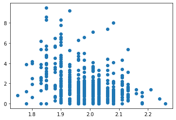

```python
fig, ax = plt.subplots()
ax.scatter(x, y)
plt.show()
```

```python
print(w)
```

[output not shown]

[figure not shown]

```python
get_h_plot(w)
```